# PS2

### Solutions to PS2, EC569 Economic Growth (University of Kent)

```python
import numpy as np
import pandas as pd
import matplotlib.pyplot as plt
%matplotlib inline
from itertools import product
```

**1.** Download [Penn World Table version 9.0 database](https://www.rug.nl/ggdc/productivity/pwt/) in your preferred format. Consider the following countries: UK, USA, Denmark, France, and Colombia.

**a.** Using data in 2014, calculate real income per worker, real capital stock per worker, and human capital index for each of the countries you picked. Report your results. Report also the variables in the data set you used. You need to look into the legend and pick the right variable.

**b.** Assume a Cobb-Douglas production function with $\alpha=1/3$. Suppose countries differ only with respect to their investment rates. For each country listed above, calculate Solow model's predicted income per capita relative to the UK income per capita. For investment rates of countries, use average of variable csh_i (Share of gross capital formation at current PPPs) over the years 1975-2014. Generate a table comparing Solow model predicted income per capita relative to the UK with actual income per capita relative to the UK (in 2014, or in the latest available year). Hint, I ask you to do an exercise same as Figure 3.7 in Weil (2013). Briefly comment on the table.

**c.** Now, assume that countries differ with respect to investment rates and population growth rates. Assume that depreciation rates in all countries are equal to 5%, $\delta=0.05$. Calculate average population growth rates of the above listed countries from 1975 to 2014. Repeat the exercise in part b. Create a table that compares Solow model's predicted income differences with actual income differences relative to the UK. Briefly comment on the table.

**d.** Now, assume that countries differ not only in their investment and population growth rates but also in their human capital. Calculate average human capital index of the above listed countries from 1975 to 2014. Assume that depreciation rates in all countries are equal to 5%, $\delta=0.05$. For this exercise use variable hc (Human capital index, based on years of schooling and returns to education). Repeat part c while considering human capital differences across countries. Create a table and briefly comment on it.

**e.** Do your predictions approach to actual income differences as you take into account more variables?

For the remaining questions we will use Penn World Table version 9.0:

Feenstra, Robert C., Robert Inklaar and Marcel P. Timmer (2015), "The Next Generation of the Penn World Table" American Economic Review, 105(10), 3150-3182, available for download at [www.ggdc.net/pwt](https://www.rug.nl/ggdc/productivity/pwt/related-research-papers/the_next_generation_of_the_penn_world_table.pdf)

```python
# Download the data
data = pd.read_excel('https://www.rug.nl/ggdc/docs/pwt90.xlsx', sheet_name='Data')
# Set country codes and years as index
data = data.set_index(['countrycode','year'])
# These are the countries that I'll plot TFP levels
```

The variables I used are

- cgdpe : Expenditure-side real GDP at current PPPs (in mil. 2011US\$)
- emp : Number of persons engaged (in millions)
- ck : Capital stock at current PPPs (in mil. 2011US\$)

```python
# First, select the data
country_codes = ['GBR','USA','DNK','FRA','COL']
data_q1a = data.loc[(country_codes,2014),:]
```

There are many variables to represent real GDP:

rgdpe: Expenditure-side real GDP at chained PPPs (in mil. 2011US$)

rgdpo: Output-side real GDP at chained PPPs (in mil. 2011US$)

cgdpe: Expenditure-side real GDP at current PPPs (in mil. 2011US$)

cgdpo: Output-side real GDP at current PPPs (in mil. 2011US$)

rgdpna: Real GDP at constant 2011 national prices (in mil. 2011US$)

```python
data_q1a = data_q1a.copy()
gdp_list = ['rgdpe','rgdpo','cgdpe','cgdpo','rgdpna']
var_list = []
for gdp in gdp_list:
    var = gdp + ' per worker'
    var_list = var_list + [var]
    data_q1a[var] = data_q1a[gdp]/data_q1a['emp']
```

```python
data_q1a[var_list].round()
```

| countrycode | year | rgdpe per worker | rgdpo per worker | cgdpe per worker | cgdpo per worker | rgdpna per worker |
| --- | --- | --- | --- | --- | --- | --- |
| COL | 2014 | 24515.0 | 25018.0 | 24353.0 | 24731.0 | 25423.0 |
| DNK | 2014 | 90385.0 | 89377.0 | 89576.0 | 87988.0 | 87396.0 |
| FRA | 2014 | 95498.0 | 93582.0 | 94660.0 | 92575.0 | 88675.0 |
| GBR | 2014 | 83612.0 | 80527.0 | 83027.0 | 79628.0 | 75913.0 |
| USA | 2014 | 112517.0 | 111799.0 | 111852.0 | 111077.0 | 111072.0 |

Variables that can be used for capital stock

ck: Capital stock at current PPPs (in mil. 2011US$)

rkna: Capital stock at constant 2011 national prices (in mil. 2011US$)

```python
data_q1a = data_q1a.copy()
cap_list = ['ck','rkna']
var_list_cap = []
for cap in cap_list:
    var = cap + ' per worker'
    var_list_cap = var_list_cap + [var]
    data_q1a.loc[:,var] = data_q1a[cap]/data_q1a['emp']
```

```python
data_q1a[var_list_cap].round()
```

| countrycode | year | ck per worker | rkna per worker |
| --- | --- | --- | --- |
| COL | 2014 | 76397.0 | 74175.0 |
| DNK | 2014 | 384622.0 | 396448.0 |
| FRA | 2014 | 443125.0 | 426984.0 |
| GBR | 2014 | 381478.0 | 326438.0 |
| USA | 2014 | 355979.0 | 344803.0 |

```python
data_q1a['rgdpe per capita'] = data_q1a['rgdpe']/data_q1a['pop']
```

'hc' in the dataset represents human capital index and an everage variable, therfore you can regard it as human capital per worker.

```python
data_q1a['hc'].round(decimals=2)
```

```
countrycode  year
COL          2014    2.49
DNK          2014    3.51
FRA          2014    3.13
GBR          2014    3.73
USA          2014    3.72
Name: hc, dtype: float64
```

In the ramaining parts of the question, we need to calculate first annual populion growth rates of the countries listed, then take averages of population growth rate, investment rate, human capital over time.

```python
data['pop growth'] = data.groupby(level=0)['pop'].pct_change()
def data_average(group):
    return group[['csh_i','delta','pop growth','hc']].mean()
data_averages = data.loc[(slice(None), slice(1975, 2014)), :].groupby(level=0).apply(data_average)
```

```python
# These are the averages we will use in our analysis:
(data_averages.loc[country_codes]).round(decimals=2)
```

| countrycode | csh_i | delta | pop growth | hc |
| --- | --- | --- | --- | --- |
| GBR | 0.21 | 0.04 | 0.00 | 3.33 |
| USA | 0.25 | 0.05 | 0.01 | 3.50 |
| DNK | 0.26 | 0.04 | 0.00 | 3.19 |
| FRA | 0.25 | 0.04 | 0.01 | 2.82 |
| COL | 0.20 | 0.04 | 0.02 | 2.06 |

```python
# since we will calculate the predictions of the Solow model relative to the UK, lets keep UK data as an easily
# accessible variable.
GBR = data_averages.loc['GBR']
```

```python
# Define the parameters of the model
alpha = 1/3
delta = 0.05
alpha_m = alpha/(1-alpha)
```

The Solow model's steady state income per worker ratio for country $i$ is equal to

$$ y_i = A_i^{1/(1-\alpha)}\left(\frac{\gamma_i}{n_i + \delta_i} \right)^{\alpha/(1-\alpha)}h_i $$

.

Then relative income per worker of country $i$ and country $j$ would be:

$$ \frac{y_i}{y_j} = \frac{A_i^{1/(1-\alpha)}\left(\frac{\gamma_i}{n_i + \delta_i} \right)^{\alpha/(1-\alpha)}h_i}{A_j^{1/(1-\alpha)}\left(\frac{\gamma_j}{n_j + \delta_j} \right)^{\alpha/(1-\alpha)}h_j} $$

If country $i$ and country $j$ differ only with respect to their investment rates:

$$\frac{y_i}{y_j} = \left( \frac{\gamma_i}{\gamma_j} \right)^{\alpha/(1-\alpha)} $$

```python
# Using the above formula, assuming country j is the UK, we get the Solow model's predicted
# income per worker ratios at the steady state:
q1_b =pd.DataFrame(((data_averages.loc[country_codes]['csh_i']/GBR['csh_i'])**alpha_m)).round(decimals=2).rename(columns={'csh_i':r'$y_i/y_{UK}$ (b)'})
q1_b
```

| countrycode | $y_i/y_{UK}$ (b) |
| --- | --- |
| GBR | 1.00 |
| USA | 1.08 |
| DNK | 1.10 |
| FRA | 1.09 |
| COL | 0.98 |

If country $i$ and $j$ differ both in investment rates and population grwoth rates, then

$$\frac{y_i}{y_j} = \left( \frac{\gamma_i}{\gamma_j} \right)^{\alpha/(1-\alpha)} \left(\frac{n_j+\delta}{n_i+\delta}\right)^{\alpha/(1-\alpha)} $$

```python
q1_c =pd.DataFrame((((data_averages.loc[country_codes]['csh_i']/GBR['csh_i'])/
 ((data_averages.loc[country_codes]['pop growth']+delta)/(GBR['pop growth']+delta)))**alpha_m)).round(decimals=2).rename(columns={0:r'$y_i/y_{UK}$ (c)'})

q1_c
```

| countrycode | $y_i/y_{UK}$ (c) |
| --- | --- |
| GBR | 1.00 |
| USA | 1.02 |
| DNK | 1.11 |
| FRA | 1.08 |
| COL | 0.87 |

If countries differ in investment rate, population growth rate, and human capital per worker, then

$$\frac{y_i}{y_j} = \left( \frac{\gamma_i}{\gamma_j} \right)^{\alpha/(1-\alpha)} \left(\frac{n_j+\delta}{n_i+\delta}\right)^{\alpha/(1-\alpha)} \frac{h_i}{h_j} $$

```python
q1_d = pd.DataFrame(((((data_averages.loc[country_codes]['csh_i']/GBR['csh_i'])/
 ((data_averages.loc[country_codes]['pop growth']+delta)/(GBR['pop growth']+delta)))**alpha_m)
 *data_averages.loc[country_codes]['hc']/GBR['hc'])).round(decimals=2).rename(columns={0:r'$y_i/y_{UK}$ (d)'})

q1_d
```

| countrycode | $y_i/y_{UK}$ (d) |
| --- | --- |
| GBR | 1.00 |
| USA | 1.08 |
| DNK | 1.06 |
| FRA | 0.91 |
| COL | 0.54 |

```python
#data_q1a.xs(2014,level=1)[['rgdpe per worker', 'rgdpe per capita']]
data_q1a.loc[:,r'$y_i/y_{UK}$ (actual, per worker)'] = data_q1a['rgdpe per worker']/data_q1a.loc['GBR']['rgdpe per worker']
data_q1a.loc[:,r'$y_i/y_{UK}$ (actual, per capita)'] = data_q1a['rgdpe per capita']/data_q1a.loc['GBR']['rgdpe per capita']
```

```python
#Now put all our findings into a single table

q1_b.join(q1_c).join(q1_d).join(data_q1a[[r'$y_i/y_{UK}$ (actual, per worker)',r'$y_i/y_{UK}$ (actual, per capita)']])
```

| countrycode | year | $y_i/y_{UK}$ (b) | $y_i/y_{UK}$ (c) | $y_i/y_{UK}$ (d) | $y_i/y_{UK}$ (actual, per worker) | $y_i/y_{UK}$ (actual, per capita) |
| --- | --- | --- | --- | --- | --- | --- |
| COL | 2014 | 0.98 | 0.87 | 0.54 | 0.293204 | 0.313094 |
| DNK | 2014 | 1.10 | 1.11 | 1.06 | 1.081006 | 1.116359 |
| FRA | 2014 | 1.09 | 1.08 | 0.91 | 1.142155 | 0.978449 |
| GBR | 2014 | 1.00 | 1.00 | 1.00 | 1.000000 | 1.000000 |
| USA | 2014 | 1.08 | 1.02 | 1.08 | 1.345712 | 1.299461 |

From the above table, it is seen that Solow model's predicted steady state income per capita ratios converges to the actual income per capita (or per worker to be more accurate) for some of the countries like Columbia abd France, but not for the US. As we control for more observables, predictions of Denmark income over UK income does not vary much.

Now, repeat the same exercise with all the countries in the data.

```python
data_averages_all = data.loc[(slice(None), slice(1975,2014)), :].groupby(level=0).apply(data_average)
```

```python
data_q1_b = ((data_averages_all['csh_i']/GBR['csh_i'])**alpha_m).round(decimals=2)
```

```python
data_q1_c = (((data_averages_all['csh_i']/GBR['csh_i'])/
 ((data_averages_all['pop growth']+delta)/(GBR['pop growth']+delta)))**alpha_m).round(decimals=2)
```

```python
data_q1_d = ((((data_averages_all['csh_i']/GBR['csh_i'])/
 ((data_averages_all['pop growth']+delta)/(GBR['pop growth']+delta)))**alpha_m)
 *data_averages_all['hc']/GBR['hc']).round(decimals=2)
```

```python
data_q1_all = data.xs(2014,level=1)
data_q1_all = data_q1_all.copy()
```

```python
data_q1_all['rgdpe per worker'] = data_q1_all['rgdpe']/ data_q1_all['emp']
data_q1_all['rgdpe per capita'] = data_q1_all['rgdpe']/ data_q1_all['pop']
data_q1_all['income per worker / UK'] = data_q1_all['rgdpe per worker']/data_q1_all.loc['GBR']['rgdpe per worker']
data_q1_all['income per capita / UK'] = data_q1_all['rgdpe per capita']/data_q1_all.loc['GBR']['rgdpe per capita']
```

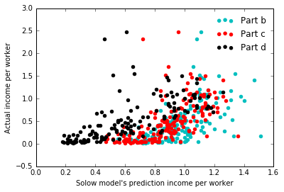

```python
plt.scatter(data_q1_b,data_q1_all['income per worker / UK'],color='c',label='Part b')
plt.scatter(data_q1_c,data_q1_all['income per worker / UK'],color='r',label='Part c')
plt.scatter(data_q1_d,data_q1_all['income per worker / UK'],color='k',label='Part d')
plt.xlabel("Solow model's prediction income per worker")
plt.ylabel("Actual income per worker")
plt.legend(loc='best',frameon=False)
```

As seen in the above graph, as we control more and more variables, Solow model's predicted steady state income per worker ratios (on average) converge to actual income per worker ratios. This convergence many not hold for individual counties, but most of the black dots representing part d are closer to the 45 degree line.

If you wrongfully calculate the growth rate from 1975 to 2014, not the average annual growth rate:

```python
data_q1_wrong = data.loc[(country_codes, [1975,2014]), :]['pop']
```

```python
pop_growth_wrong = data_q1_wrong.groupby('countrycode').pct_change().xs(2014,level=1).round(decimals=3)
```

```python
pop_growth_wrong
```

```
countrycode
COL    0.930
DNK    0.116
FRA    0.219
GBR    0.145
USA    0.459
Name: pop, dtype: float64
```

```python
(((data_averages.loc[country_codes]['csh_i']/GBR['csh_i'])/
 ((pop_growth_wrong+delta)/(pop_growth_wrong.loc['GBR']+delta)))**alpha_m).round(decimals=2)
```

```
countrycode
COL    0.44
DNK    1.20
FRA    0.93
GBR    1.00
USA    0.67
dtype: float64
```

```python
((((data_averages.loc[country_codes]['csh_i']/GBR['csh_i'])/
 ((pop_growth_wrong+delta)/(pop_growth_wrong.loc['GBR']+delta)))**alpha_m)
 *data_averages.loc[country_codes]['hc']/GBR['hc']).round(decimals=2)
```

```
countrycode
COL    0.27
DNK    1.15
FRA    0.79
GBR    1.00
USA    0.71
dtype: float64
```

**2.** Using [Penn World Table](https://www.rug.nl/ggdc/productivity/pwt/), plot Total Factor Productivities (TFP) in the United Kingdom, Germany, and France relative to the United States for all the available years. The variable you need to plot is ctfp (TFP level at current PPPs (USA=1)). Briefly comment on your plot.

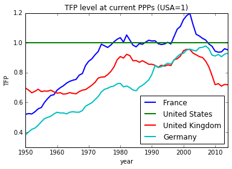

```python
# Download the data
#data = pd.read_excel('https://www.rug.nl/ggdc/docs/pwt90.xlsx', sheet_name='Data')
# Set country codes and years as index
#data = data.set_index(['countrycode','year'])
# These are the countries that I'll plot TFP levels
country_codes = ['FRA','USA','GBR','DEU']
for code in country_codes:
    country = data.loc[code]
    country['ctfp'].plot(label=country.iloc[0]['country'],linewidth=2)
plt.legend(loc='best')
plt.ylabel('TFP')
plt.title('TFP level at current PPPs (USA=1)')
```

```python
country_codes = ['FRA','GBR','DEU']
data2 = data.loc[(country_codes,(1950,1980,2000,2014)),:]['ctfp'].unstack()

data2['1950-1980']=(data2[1980]/data2[1950])**(1/30)-1
data2['1980-2000']=(data2[2000]/data2[1980])**(1/20)-1
data2['2000-2014']=(data2[2014]/data2[2000])**(1/14)-1

data2.round(decimals=3)
```

| year countrycode | 1950 | 1980 | 2000 | 2014 | 1950-1980 | 1980-2000 | 2000-2014 |
| --- | --- | --- | --- | --- | --- | --- | --- |
| DEU | 0.384 | 0.728 | 0.929 | 0.930 | 0.022 | 0.012 | 0.000 |
| FRA | 0.521 | 1.035 | 1.156 | 0.953 | 0.023 | 0.006 | -0.014 |
| GBR | 0.697 | 0.908 | 0.947 | 0.719 | 0.009 | 0.002 | -0.020 |

**3.** Using the Penn World Table, conduct development accounting of Argentina, Germany, Bulgaria and Japan relative to the United Kingdom. Use 2014 values of cgdpe and ck as measures of income and capital stock. Take hc as a measure of human capital per worker. You don’t need to divide hc with employment numbers. Create a table similar to Table 7.2 of Weil (2013). Briefly comment on the table.

**Solution:** First, for each country, calculate income per worker and capital stock per worker by dividing 'cgdpe' and 'ck' by 'emp' (employment). Second, divide income per worker, capital per worker, human capital per worker by the Great Britain values.

Lastly, calculate productivity differences as follows: $$\frac{A_i}{A_{GBR}}=\frac{\frac{y_i}{y_{GBR}}}{\frac{k_i^\alpha h_i^{1-\alpha}}{k_{GBR}^\alpha h_{GBR}^{1-\alpha}}}$$

The variables we use are

cgdpe: Expenditure-side real GDP at current PPPs (in mil. 2011US\$)

ck: Capital stock at current PPPs (in mil. 2011US\$)

emp: Number of persons engaged (in millions)

```python
key = 'emp'
# income and capital per worker for this question
data['income per worker (3)'] = data['cgdpe']/data[key]
data['capital per worker (3)'] = data['ck']/data[key]

# income and capital per worker for question 4
data['income per worker (4)'] = data['rgdpna']/data[key]
data['capital per worker (4)'] = data['rkna']/data[key]

# select 2014 values
data_2014 = data.xs(2014,level=1)
data_2014 = data_2014.dropna(subset=('income per worker (3)','capital per worker (3)','hc'))
GBR = data_2014.loc['GBR']

# relative to the uk
data_2014['Output per worker, y'] = data_2014['income per worker (3)']/GBR['income per worker (3)']
data_2014['Physical capital per worker, k'] = data_2014['capital per worker (3)']/GBR['capital per worker (3)']
data_2014['Human capital per worker, h'] = data_2014['hc']/GBR['hc']

# factors of production relative to the UK
data_2014['Factors of production'] = (data_2014['Physical capital per worker, k']**(1/3)*
                                      data_2014['Human capital per worker, h']**(2/3))

# productivity relative to the UK
data_2014['Productivity, A'] = data_2014['Output per worker, y']/data_2014['Factors of production']

country_codes = ['ARG','DEU','BGR','JPN']
a = list(product(country_codes,[2014]))

data_2014.loc[country_codes][['country','Output per worker, y','Physical capital per worker, k',
                              'Human capital per worker, h','Factors of production',
                              'Productivity, A']].round(decimals=2)
```

| countrycode | country | Output per worker, y | Physical capital per worker, k | Human capital per worker, h | Factors of production | Productivity, A |
| --- | --- | --- | --- | --- | --- | --- |
| ARG | Argentina | 0.58 | 0.31 | 0.79 | 0.58 | 1.00 |
| DEU | Germany | 1.04 | 0.94 | 0.98 | 0.97 | 1.08 |
| BGR | Bulgaria | 0.42 | 0.23 | 0.84 | 0.54 | 0.78 |
| JPN | Japan | 0.83 | 0.74 | 0.95 | 0.87 | 0.95 |

German productivity is 8 percent higher than the British but German capital per worker is 6 percent lower and German human capital stock per worker is 2 percent lower than British counterparts. Higher productivity attenuated impacts of lower physical and human capital and overall Germany produces 4 percent more per worker than the United Kingdom.

Bulgaria has lower physical capital (77%), lower human capital (16%) and lower productivity (22%) than the UK. These all corresponds to 58% lower output per worker in Bulgaria than in the United Kingdom.

Japanese values are quite surprising. We calculate that Japan has 26% less capital per worker than the UK, but Table 7.2 of the textbook (Weil, 2013) estimates that Japan has 70 percent more capital per worker. This may be due to the fact that physical capital stock measure we use here is different than Weil (2013)'s calculations, and physical capital is prone to significant measurement errors. However, here, Japan has 5 percent less productivity than the UK.

**4.** Using the Penn World Table, conduct growth accounting of Italy, Greece, Spain, South Korea and the United Kingdom. Examine data from 1975 to 2014. Use rgdpna and rkna as output and capital stock measures. Create a table (similar to Table 7.3 of the textbook). Briefly comment on the table.

**Solution:** First, calculate growth rates per year from 1975 to 2014, $$ g_y = \left(\frac{y_{2014}}{y_{1975}} \right)^{1/39}-1 $$ $$ g_k = \left(\frac{k_{2014}}{k_{1975}} \right)^{1/39}-1 $$ $$ g_h = \left(\frac{h_{2014}}{h_{1975}} \right)^{1/39}-1 $$

Assuming $y=A k^\alpha h^{1-\alpha}$, then $g_y = g_A + \alpha g_k + (1-\alpha)g_h$. Therefore, growth rate of productivity is $$g_A = g_y - \alpha g_k - (1-\alpha)g_h$$.

Lastly, contribution of productivity growth to income growth is equal to $g_A/g_y$, contribution of physical capital growth to income growth is $\alpha g_k/g_y$, and contribution of human capital growth to income growth is $(1-\alpha)g_h/g_y$

The variables we use are

rgdpna: Real GDP at constant 2011 national prices (in mil. 2011US\$)

rkna: Capital stock at constant 2011 national prices (in mil. 2011US\$)

```python
# create growth rate of factors as described above

country_codes=['ITA','GRC','ESP','KOR','GBR']

data_q4=data.loc[(country_codes,(1975,2014)),:][['hc','income per worker (4)','capital per worker (4)']]
```

```python
# here is our data, as specified in the question we use rgdpna and rkna as measures of output and capital
# stock per worker since these are more suitable to calculate growth rates within a country
data_q4.round(decimals=2)
```

| countrycode | year | hc | income per worker (4) | capital per worker (4) |
| --- | --- | --- | --- | --- |
| ESP | 1975 | 2.13 | 44221.12 | 145610.73 |
|  | 2014 | 2.88 | 81335.30 | 475410.57 |
| GBR | 1975 | 2.85 | 39297.02 | 193547.62 |
|  | 2014 | 3.73 | 75913.50 | 326437.77 |
| GRC | 1975 | 2.18 | 43025.26 | 167967.30 |
|  | 2014 | 3.03 | 61508.33 | 394343.23 |
| ITA | 1975 | 2.17 | 53250.07 | 220035.31 |
|  | 2014 | 3.07 | 84554.17 | 501971.93 |
| KOR | 1975 | 2.18 | 11441.19 | 19243.10 |
|  | 2014 | 3.59 | 66165.62 | 254760.36 |

```python
# now calucalate the factor growth rates and productivity growth rates using formulas described above
def growth_rates(group):
    return (group.iloc[-1]/group.iloc[-0])**(1/39)-1

data_growth=data_q4.groupby('countrycode').apply(growth_rates)

alpha=1/3
data_growth['productivity'] = (data_growth['income per worker (4)'] - alpha*data_growth['capital per worker (4)']
                               - (1-alpha)*data_growth['hc'])
```

```python
(data_growth*100).round(decimals=3)
```

| countrycode | hc | income per worker (4) | capital per worker (4) | productivity |
| --- | --- | --- | --- | --- |
| ESP | 0.781 | 1.575 | 3.080 | 0.027 |
| GBR | 0.691 | 1.703 | 1.349 | 0.792 |
| GRC | 0.840 | 0.921 | 2.212 | -0.377 |
| ITA | 0.886 | 1.193 | 2.137 | -0.110 |
| KOR | 1.295 | 4.603 | 6.848 | 1.457 |

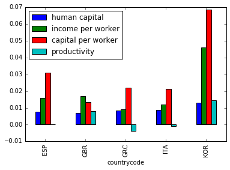

```python
data_growth.columns= 'human capital','income per worker','capital per worker', 'productivity'
data_growth.plot(kind='bar')
```

In Spain, from 1975 to 2014, human capital increased by .8 percent per year, capital per worker increased by 3.1 percent per year and productivity remained constant (more or less). These change led to 1.6% increase in output per worker per year.

The Great Britain, on the other hand, increased its human capital by .7 percent per year, physical capital 1.3 percent per year, and productivity by .8 percent per year. All these constibuted to 1.7 percent increase in income per worker per year.

South Korea had a robust growh in this time period. Income per worker increased 4.6% per year, mainly due to capital accumulation (6.8% increase per year), productivity increase (1.5%) and human capital accumulation (1.3% increase per year). Our findings regarding South Korea mirrors results of Young (1995).

Increase in capital per worker is the largest in Korea, then comes Spain. It's the smallest in the UK. Income per worker increased the most in South Korea, and it increased the least in Greece.

```python
# now let's calculate contribution of each factor to income growth
weight = np.array([(1/(1-alpha),1/alpha,1)])
weight.shape = (1,3)
income = data_growth['income per worker'].values
income.shape = (5,1)
data_growth_cont = data_growth[['human capital','capital per worker','productivity']]/income.dot(weight)
(data_growth_cont).round(2)
```

| countrycode | human capital | capital per worker | productivity |
| --- | --- | --- | --- |
| ESP | 0.33 | 0.65 | 0.02 |
| GBR | 0.27 | 0.26 | 0.47 |
| GRC | 0.61 | 0.80 | -0.41 |
| ITA | 0.50 | 0.60 | -0.09 |
| KOR | 0.19 | 0.50 | 0.32 |

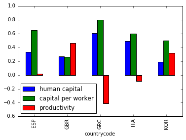

```python
data_growth_cont.plot(kind='bar')
```

Now analyze how each factor of production and productivity contribute to economic growth. In Spain, Greece, Italy, and Korea phyical capital accumulation contributes the most to income growth: 65%, 80%, 60% and 50%. In the Great Britain productivity growth contributed the most to the income growth by 47%. Productivity growh in Greece and Italy were negative in these time periods, and hence we see negative contributions of productivity to income growth in these countries. In all these countries, human capital accumlation contributed substantially to income growth: 33% in Spain, 27% in the UK, 61% in Greece, 50% in Italy, and 19% in Korea.

Alternatively, if you have used 'cgdpe' as the income variable, you should get a result depicted in the table below:

```python
data_q4_alt = data.loc[(slice(None), (1975, 2014)),:]
data_q4_alt=data_q4_alt.loc[country_codes][['hc','income per worker (3)','capital per worker (4)']]

data_growth_alt=data_q4_alt.groupby('countrycode').apply(growth_rates)
alpha=1/3
data_growth_alt['productivity'] = (data_growth_alt['income per worker (3)'] - alpha*data_growth_alt['capital per worker (4)']
                               - (1-alpha)*data_growth_alt['hc'])

data_growth_alt.round(3)
```

| countrycode | hc | income per worker (3) | capital per worker (4) | productivity |
| --- | --- | --- | --- | --- |
| ESP | 0.008 | 0.025 | 0.031 | 0.009 |
| GBR | 0.007 | 0.023 | 0.013 | 0.014 |
| GRC | 0.008 | 0.021 | 0.022 | 0.008 |
| ITA | 0.009 | 0.021 | 0.021 | 0.008 |
| KOR | 0.013 | 0.043 | 0.068 | 0.012 |

**5.** Consider the extended Solow model. Suppose the production function is $Y = K^\alpha (ehL)^{1-\alpha}.$

**a.** Derive change in capital per effective worker, $\dot{\tilde{k}}$, as a function of capital per effective worker, $\tilde{k}$, and other exogenous variables in the model.

**b.** Suppose that investment rate is 20%, $\gamma =.2$, depreciation rate is 5%, $\delta=.05$, population growth rate is 1%, $n=.01$, labor-augmenting technological progress rate is 2%, $g = .02$, human capital is equal to 1, $h=1$, and capital income share is .33, $\alpha=.33$. Find steady state capital per effective worker, income per effective worker, consumption per effective worker.

**c.** Suppose at time $t=0$, the economy is at the steady state, and level of labor-augmenting technology is equal to 1, $e(0)=1$. What's the income per worker level at time $t=20$? Remember that if a variable (say M) grows at a constant rate, say m, then the value of M at time $t$ is equal to $\exp(mt)$ times the value of M at time $0$, i.e. $M(t)=M(0)\exp(mt).$

**d.** Suppose again that at time $t=0$, the economy is at the steady state, and level of labor-augmenting technology is equal to 1, $e(0)=1$. Now, suddenly (and unexpectedly) the labor-augmenting technology increases by 10\%, i.e. $e^{new}(0) = 1.1e(0)$, and then $e^{new}$ grows at a constant rate of $g=.02$. Simulate the model for 100 periods, and calculate capital per effective worker, capital per worker, income per effective worker, and income per worker at each time period.

```python
# Assign parameter values
T = 100
alpha = .33
alpha_m = 1 / (1-alpha)
gamma = .2
delta = .05
g = 0.02
n = .01
h = 1
# sequence of capital per worker and output per worker to be filled later.
k_tilde_seq  = np.zeros(T)
y_tilde_seq  = np.zeros(T)
```

Steady state values $$\tilde{k}= \left(\frac{\gamma}{\delta+n+g}\right)^{1/(1-\alpha)}h $$ $$\tilde{y}= \tilde{k}^\alpha h^{1-\alpha}$$ $$\tilde{c}= (1-\gamma)\tilde{y}$$

```python
# find the steady state values
k_tilde_ss = (gamma/(delta+n+g))**alpha_m*h
y_tilde_ss = k_tilde_ss**alpha*h**(1-alpha)
c_tilde_ss = (1-gamma)*y_tilde_ss
```

```python
# steady state capital per effective worker, income per effective worker, and consumption per effective worker
print(np.round(np.array([k_tilde_ss,y_tilde_ss,c_tilde_ss]),decimals=2))
```

```
[3.93 1.57 1.26]
```

Income per capita at time $t$ at the steady state is equal to $$y(t) = \tilde{y} \exp(gt) $$

```python
# income per capita at time 20 is equal to
(y_tilde_ss*np.exp(g*20)).round(decimals=2)
```

```
2.34
```

In this question, the key observation you need to make is after the jump in labor augmenting technology, capital per effective worker goes down. To see this, remember the definition capital per effective worker, $\tilde{k} = \frac{K}{eL}$. At the instant of the shock, $K$ and $L$ are predetermined (or they don't change). However, $e$ goes up by 10 percent, hence $\tilde{k}$ goes down. $\tilde{k}^{new} = \frac{\tilde{k}}{1.1}$. After we made this observation, we can simulate our model starting from $\tilde{k}^{new}$.

```python
# an auxiliary capital stock sequence equal to steady state capital per worker
k_sseq = np.ones(T+10)*k_tilde_ss
y_sseq = np.ones(T+10)*y_tilde_ss

# inital capital per effective worker, income per effective worker
k_tilde_seq[0] = k_tilde_ss/1.1
y_tilde_seq[0] = k_tilde_seq[0]**alpha*h**(1-alpha)

# for a given capital per worker, first find the change in capital per worker
# add the change in capital per worker to the capital per worker at the beginning of the period
# calculate income with the new capital per worker
# loop over all time years
for t in range(1,T):
    k_dot = gamma*y_tilde_seq[t-1]-(delta+n+g)*k_tilde_seq[t-1]
    k_tilde_seq[t]= k_tilde_seq[t-1]+k_dot
    y_tilde_seq[t]=k_tilde_seq[t]**alpha*h**(1-alpha)
k_tilde_seq = np.append(np.ones(10)*k_tilde_ss,k_tilde_seq)
y_tilde_seq = np.append(np.ones(10)*y_tilde_ss,y_tilde_seq)
```

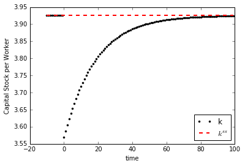

```python
# plot out results
plt.plot(np.arange(-10,T),k_tilde_seq,'k.',linewidth=2,label='k')
plt.plot(np.arange(-10,T),k_sseq,'r--',linewidth=2, label=r'$k^{ss}$')
plt.xlabel('time')
plt.ylabel('Capital Stock per Worker')
plt.legend(loc='best')
plt.savefig('q5_d-1.pdf')
```

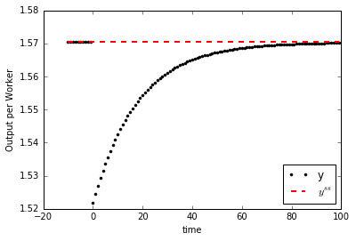

```python
# plot output per effective worker
plt.plot(np.arange(-10,T),y_tilde_seq,'k.',linewidth=2,label='y')
plt.plot(np.arange(-10,T),y_sseq,'r--',linewidth=2, label=r'$y^{ss}$')
plt.xlabel('time')
plt.ylabel('Output per Worker')
plt.legend(loc='best')
plt.savefig('q5_d-2.pdf')
```

As seen from the above graphs, after the inital shock, both capital per effective worker and income per effective worker goes down initially, then converges to their steady state values.

```python
# now calculate the labor augmenting technology levels as described in the question
e_seq = np.array([np.exp(g*t)*1.1 for t in range(100)])
```

```python
# y and k are just e multipled by k_tilde and y_tilde
k_seq = k_tilde_seq[10:]*e_seq
y_seq = y_tilde_seq[10:]*e_seq
```

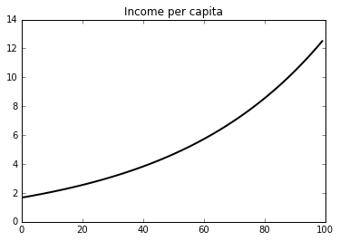

```python
plt.plot(y_seq,'k',linewidth=2)
plt.title('Income per capita')
```

```python
# income per worker at t=30
y_seq[30].round(decimals=2)
```

```
3.13
```

```python
# capital per worker at t=40
k_seq[40].round(decimals=2)
```

```
9.51
```

```python
# to understant what happens at the time of the shock, let's plot y and k starting 10 periods before the event
e_seq = np.array([np.exp(g*t) for t in range(-10,0)]+[np.exp(g*t)*1.1 for t in range(100)])
```

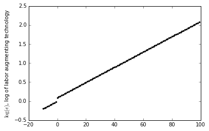

```python
plt.plot(np.arange(-10,T),np.log(e_seq),'k.')
plt.ylabel(r'$\log(e)$, log of labor augmenting technology')
```

Labor augmenting technology was increasing at a constant rate, suddenly it jumps up, and keeps increasing at the same constant rate.

```python
k_seq = k_tilde_seq*e_seq
y_seq = y_tilde_seq*e_seq
```

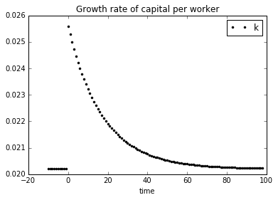

```python
# plot out results
plt.plot(np.arange(-10,T-1),np.diff(k_seq)/k_seq[:-1],'k.',linewidth=2,label='k')
plt.xlabel('time')
plt.title('Growth rate of capital per worker')
plt.legend(loc='best')
```

Capital per worker was growing at a constant rate of $g$ before the event. After the event, growth rate of capital per worker jumps up, as the economy begins accumulation capital per worker. As time goes, the growth rate of capital per worker goes down to its steady state growth rate becuase capital accumulation slows down. In the new steady state, capital per worker grows because of technological progress.

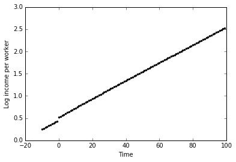

```python
plt.plot(np.arange(-10,T),np.log(y_seq),'k.')
plt.xlabel('Time')
plt.ylabel('Log income per worker')
```

After the shock, income per worker jumps up as the technology jumps up. To understant this, notice that $y(0) = \tilde{y}(0) e(0) = \tilde{k}^\alpha h^{1-\alpha} e(0) = \left( \frac{K(0)}{e(0)L(0)}\right)^{\alpha}h^{1-\alpha}e(0)=\left( \frac{K(0)}{L(0)}\right)^{\alpha}h^{1-\alpha}e(0)^{1-\alpha}$. At time $t=0$ the shock does not impact $K(0)$ or $L(0)$, but $e(0)$ goes up by 10 percent, and hence $y(0)$ goes up by $.1(1-\alpha)$

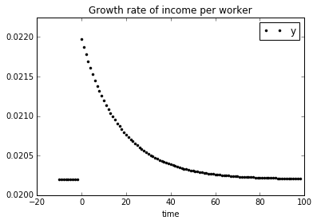

```python
# plot out results
plt.plot(np.arange(-10,T-1),np.diff(y_seq)/y_seq[:-1],'k.',linewidth=2,label='y')
plt.xlabel('time')
plt.ylim(ymax=.02225)
plt.title('Growth rate of income per worker')
plt.legend(loc='best')
```

Note that, in the above graph, I don't show the growth rate of y at the time of the shock. However, after the event, $y$ grows at a high rate because of accumulation of capital. Growth rate of $y$ converges down to its steady state growth rate, which is equal to $g.$